# Act Report

### Data Analysis Professional Nanodegree Program

### We Rate Dogs Data

This work is dedicated for **Wrangle and Analyza Data Project**. The second project in **Data Analysis Professional Nanodegree Program**.

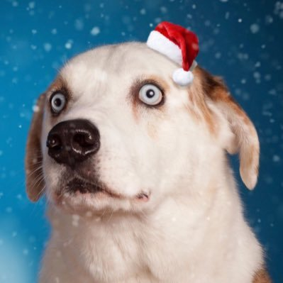

# Insights

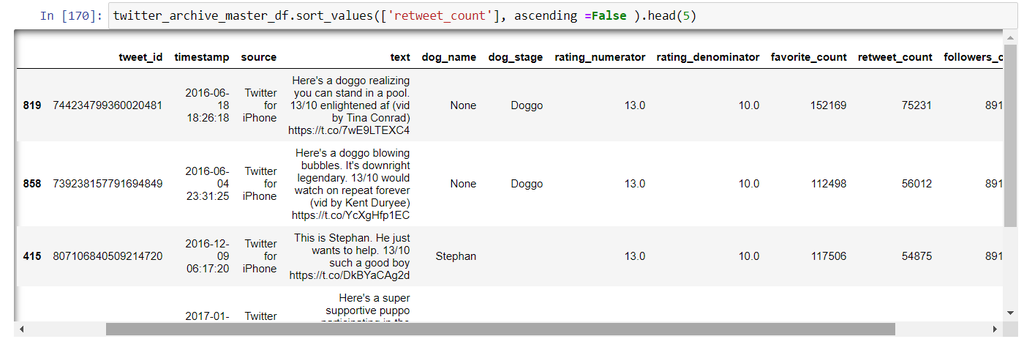

### Golden Retriever is the most predicted dog

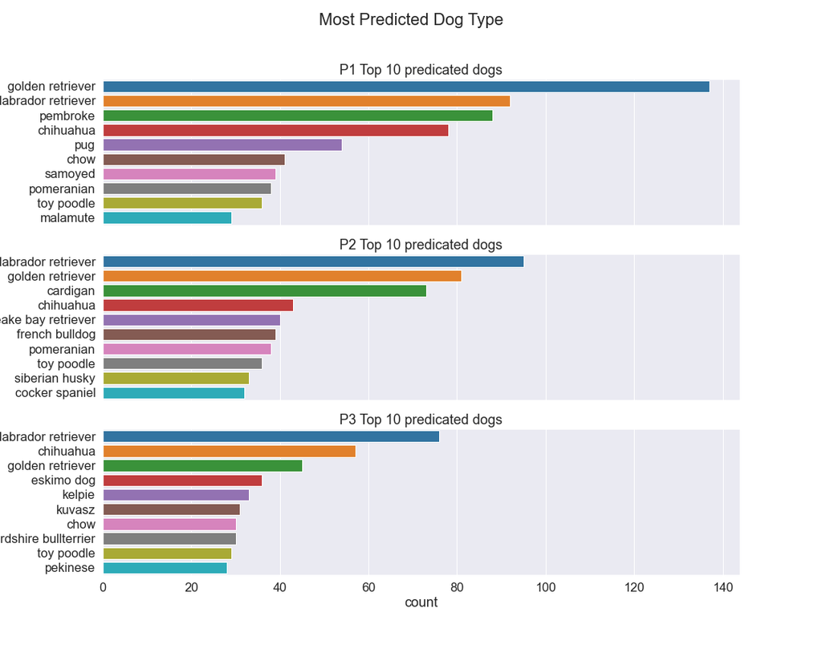

### There is a proportional relationship between retweets counts and favourite counts

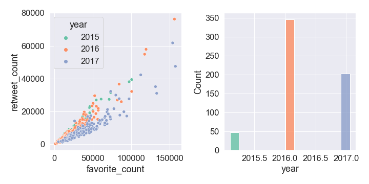

### Even Pupper stage dogs are the most dominant in the count, but Puppo stage dogs genereated the most interaction.

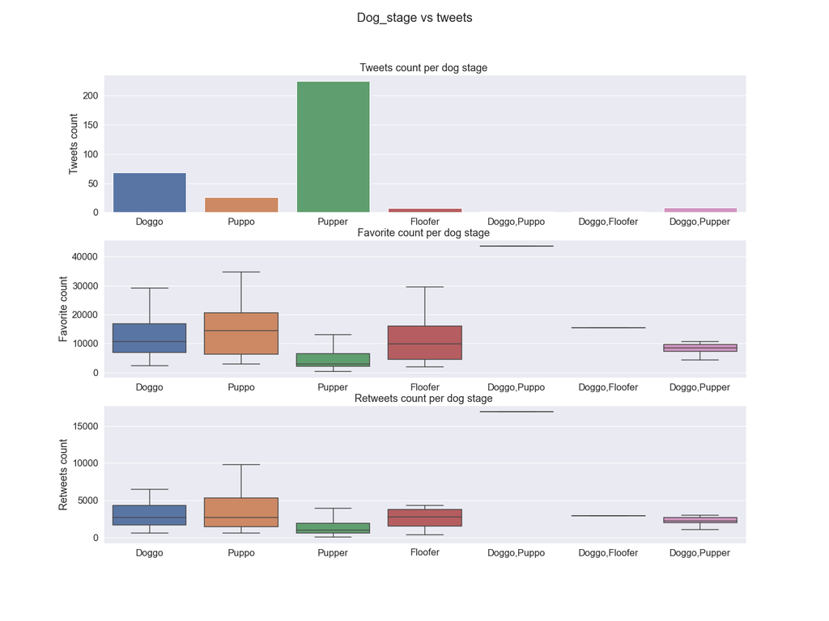

### iPhone is the most important plafrom for future updates

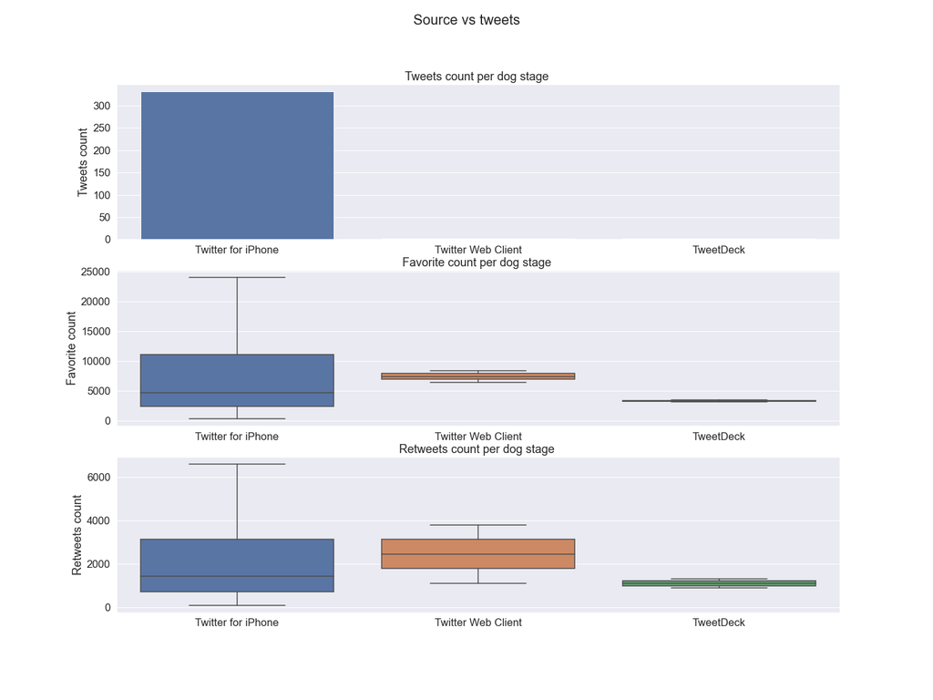

### The extracted data starting from November-2015 to July-2017. The more interacion from Twitter users with this account depend on quality of tweets not the number of tweets. Followers number didn'd change so much over this period. While 2016 has the biggest total retweets and favorites but 2017 was higer in mean.

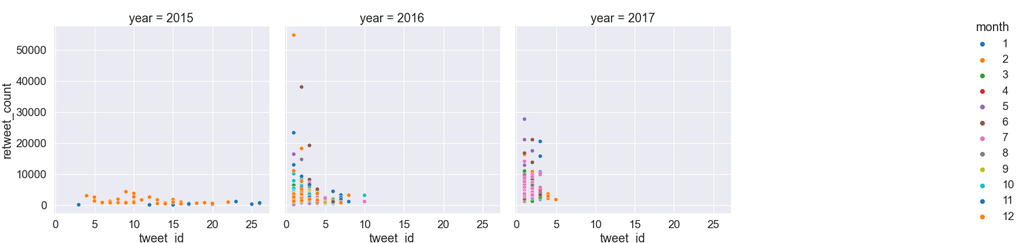

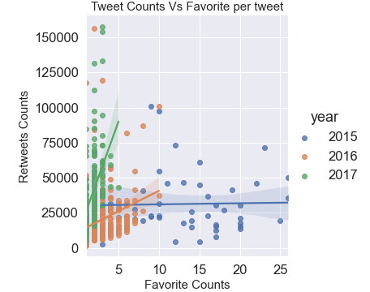

# Notes

- If the photo include more than one dog the rating will be much bigger than usual
- Not dog pictures take lowest rating as well as poor quality pictures
- the highest rate is for a picture of **Snoop Dogg**
- some of predicted images was extracted from a video like with **tweet_id: 744234799360020481**

> Say hello to this unbelievably well behaved squad of doggos. 204/170 would try to pet all at once [pic.twitter.com/yGQI3He3xv](https://t.co/yGQI3He3xv)

> — WeRateDogs® (@dog_rates) [May 13, 2016](https://twitter.com/dog_rates/status/731156023742988288?ref_src=twsrc%5Etfw)

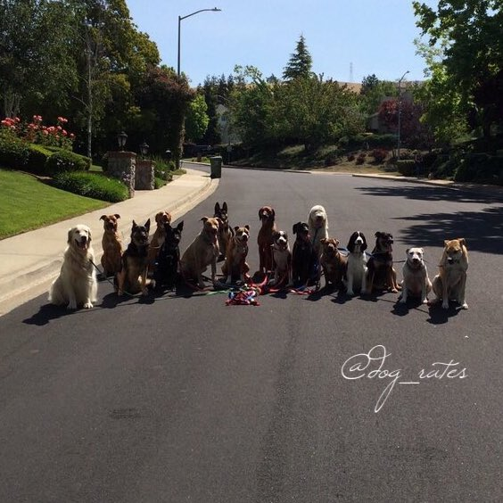

> This is Wesley. He's clearly trespassing. Seems rather h*ckin violent too. Weaponized forehead. 3/10 wouldn't let in [pic.twitter.com/pL7wbMRW7M](https://t.co/pL7wbMRW7M)

> — WeRateDogs® (@dog_rates) [September 19, 2016](https://twitter.com/dog_rates/status/777885040357281792?ref_src=twsrc%5Etfw)

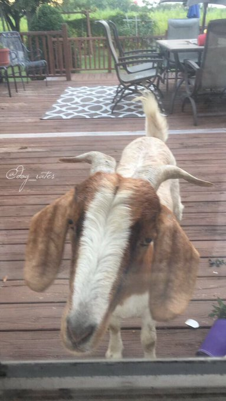

> This is a western brown Mitsubishi terrier. Upset about leaf. Actually 2 dogs here. 7/10 would walk the shit out of [pic.twitter.com/r7mOb2m0UI](https://t.co/r7mOb2m0UI)

> — WeRateDogs® (@dog_rates) [November 15, 2015](https://twitter.com/dog_rates/status/666029285002620928?ref_src=twsrc%5Etfw)

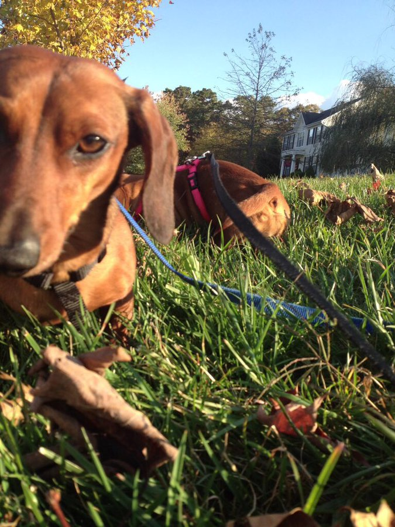